# Détection de Fraude Fiscale — Rapport Analytique

Profession : Exec-managerial

Groupe 4 — M1 R Avancée

04 June 2026

# Résumé exécutif

Ce rapport est **filtré sur la profession : Exec-managerial**. Il analyse les caractéristiques spécifiques de ce groupe et évalue leur risque de sous-déclaration fiscale (revenu > 50 K$).

> **Périmètre d’analyse :** Exec-managerial — 5 984 individus

KPIs Clés — Exec-managerial

| Indicateur | Valeur |
| --- | --- |
| Individus analysés | 5 984 |
| Individus >50K$ | 2 867 |
| Taux de risque | 47.9% |
| AUC-ROC final | 0.884 |

- **Individus totaux** : 5 984
- **Individus >50K$** : 2 867
- **Taux de risque** : 47.9%
- **AUC-ROC final** : 0.884

# 1 Présentation des données

Les statistiques ci-dessous portent uniquement sur les individus de la profession **Exec-managerial** (n = 5984).

## 1.1 Description des variables

```r
tibble(
  Variable = col_names,
  Description = c(
    "Âge de l'individu", "Classe de travail (8 niveaux)",
    "Poids de pondération finale", "Niveau d'éducation (16 niveaux)",
    "Niveau d'éducation (numérique)", "Statut marital (7 niveaux)",
    "Catégorie professionnelle (14 niveaux)", "Relation dans le foyer (6 niveaux)",
    "Origine ethnique (5 niveaux)", "Sexe (binaire)",
    "Gains en capital (USD)", "Pertes en capital (USD)",
    "Heures travaillées par semaine", "Pays d'origine (41 niveaux)",
    "Revenu > 50K$ (cible binaire)"
  ),
  Type = c(
    "Numérique", "Catégorielle", "Numérique", "Catégorielle",
    "Numérique", "Catégorielle", "Catégorielle", "Catégorielle",
    "Catégorielle", "Binaire", "Numérique", "Numérique",
    "Numérique", "Catégorielle", "Binaire"
  )
) %>%
  gt() %>%
  tab_header(title = "Description des variables — Adult Income Dataset") %>%
  tab_style(style = cell_fill(color = "#EBF5FB"),
            locations = cells_body(rows = seq(1, 15, 2)))
```

Description des variables — Adult Income Dataset

| Variable | Description | Type |
| --- | --- | --- |
| age | Âge de l'individu | Numérique |
| workclass | Classe de travail (8 niveaux) | Catégorielle |
| fnlwgt | Poids de pondération finale | Numérique |
| education | Niveau d'éducation (16 niveaux) | Catégorielle |
| education_num | Niveau d'éducation (numérique) | Numérique |
| marital_status | Statut marital (7 niveaux) | Catégorielle |
| occupation | Catégorie professionnelle (14 niveaux) | Catégorielle |
| relationship | Relation dans le foyer (6 niveaux) | Catégorielle |
| race | Origine ethnique (5 niveaux) | Catégorielle |
| sex | Sexe (binaire) | Binaire |
| capital_gain | Gains en capital (USD) | Numérique |
| capital_loss | Pertes en capital (USD) | Numérique |
| hours_per_week | Heures travaillées par semaine | Numérique |
| native_country | Pays d'origine (41 niveaux) | Catégorielle |
| income | Revenu > 50K$ (cible binaire) | Binaire |

## 1.2 Valeurs manquantes avant nettoyage

```r
adult_raw %>%
  mutate(income = str_remove(income, "\\.") %>% str_trim()) %>%
  clean_names() %>%
  mutate(across(where(is.character), ~ na_if(., "?"))) %>%
  summarise(across(everything(), ~ sum(is.na(.)))) %>%
  pivot_longer(everything(), names_to = "Variable", values_to = "NA_count") %>%
  filter(NA_count > 0) %>%
  mutate(pct = percent(NA_count / nrow(adult_raw), accuracy = 0.1)) %>%
  gt() %>%
  tab_header(title = "Variables avec valeurs manquantes ('?')") %>%
  cols_label(Variable = "Variable", NA_count = "Nb. NA", pct = "% NA")
```

Variables avec valeurs manquantes ('?')

| Variable | Nb. NA | % NA |
| --- | --- | --- |
| workclass | 2799 | 5.7% |
| occupation | 2809 | 5.8% |
| native_country | 857 | 1.8% |

## 1.3 Déséquilibre de classes

```r
adult_fe %>%
  count(income) %>%
  mutate(Proportion = percent(n / sum(n), accuracy = 0.1)) %>%
  gt() %>%
  tab_header(title = sprintf("Répartition de `income` — %s", label_occ))
```

Répartition de `income` — Exec-managerial

| income | n | Proportion |
| --- | --- | --- |
| >50K | 2867 | 47.9% |
| <=50K | 3117 | 52.1% |

# 2 Analyse exploratoire

Tous les graphiques ci-dessous sont calculés sur le sous-ensemble **Exec-managerial** uniquement.

## 2.1 Distribution de la variable cible

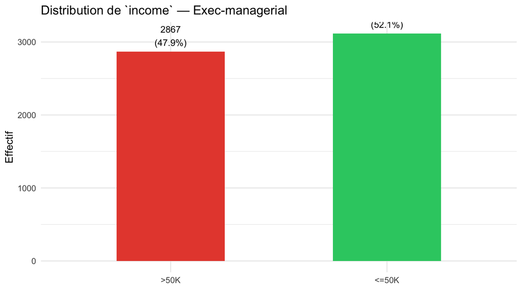

```r
adult_fe %>%
  count(income) %>%
  mutate(pct = n / sum(n) * 100) %>%
  ggplot(aes(x = income, y = n, fill = income)) +
  geom_col(width = 0.5, show.legend = FALSE) +
  geom_text(aes(label = sprintf("%d\n(%.1f%%)", n, pct)), vjust = -0.3, size = 4) +
  scale_fill_manual(values = c("#E74C3C", "#2ECC71")) +
  labs(title = sprintf("Distribution de `income` — %s", label_occ),
       x = NULL, y = "Effectif") +
  theme_minimal(base_size = 13)
```

## 2.2 Distribution de l’âge

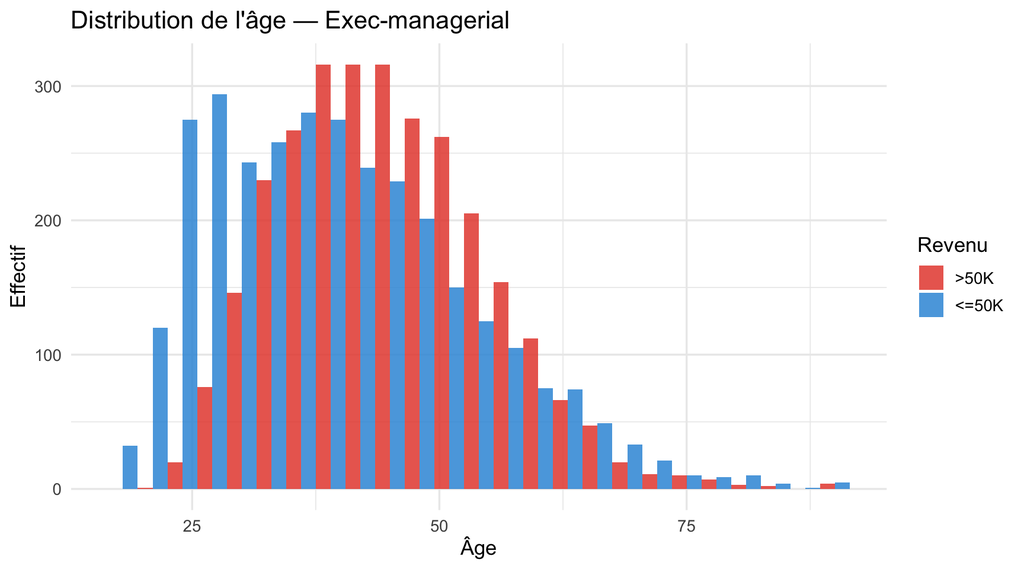

```r
adult_fe %>%
  ggplot(aes(x = age, fill = income)) +
  geom_histogram(binwidth = 3, position = "dodge", alpha = 0.85) +
  scale_fill_manual(values = c("#E74C3C", "#3498DB")) +
  labs(title = sprintf("Distribution de l'âge — %s", label_occ),
       x = "Âge", y = "Effectif", fill = "Revenu") +
  theme_minimal(base_size = 13)
```

> **Profil Exec-managerial :** age median = 41 ans, taux >50K$ = 47.9%.

## 2.3 Capital gain par classe

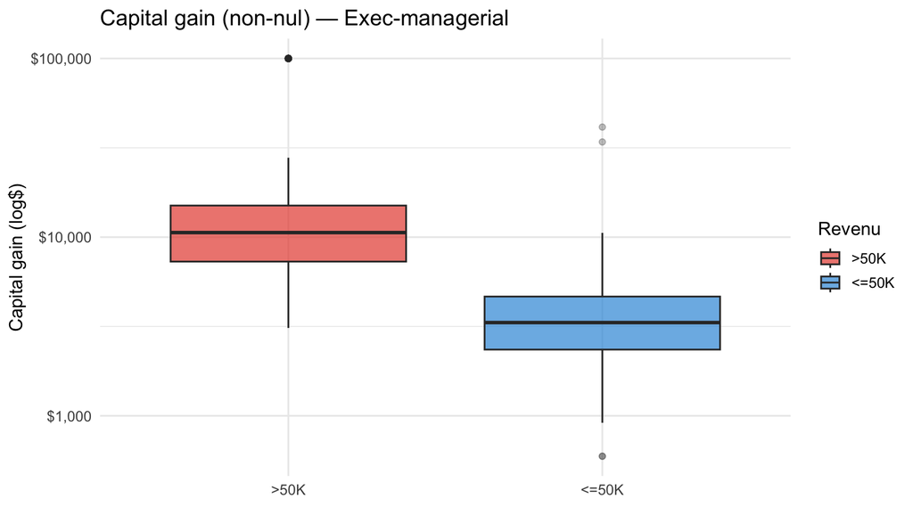

```r
adult_fe %>%
  filter(capital_gain > 0) %>%
  ggplot(aes(x = income, y = capital_gain, fill = income)) +
  geom_boxplot(alpha = 0.7, outlier.alpha = 0.3) +
  scale_y_log10(labels = dollar) +
  scale_fill_manual(values = c("#E74C3C", "#3498DB")) +
  labs(title = sprintf("Capital gain (non-nul) — %s", label_occ),
       x = NULL, y = "Capital gain (log$)", fill = "Revenu") +
  theme_minimal(base_size = 13)
```

## 2.4 Heures travaillées par semaine

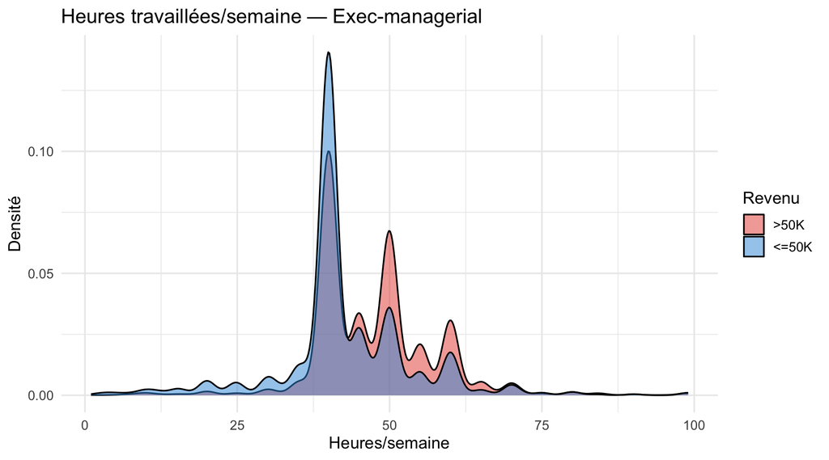

```r
adult_fe %>%
  ggplot(aes(x = hours_per_week, fill = income)) +
  geom_density(alpha = 0.5) +
  scale_fill_manual(values = c("#E74C3C", "#3498DB")) +
  labs(title = sprintf("Heures travaillées/semaine — %s", label_occ),
       x = "Heures/semaine", y = "Densité", fill = "Revenu") +
  theme_minimal(base_size = 13)
```

> Parmi les **Exec-managerial**, 18.6% travaillent plus de 50h/semaine.

## 2.5 Taux de >50K$ par niveau d’éducation

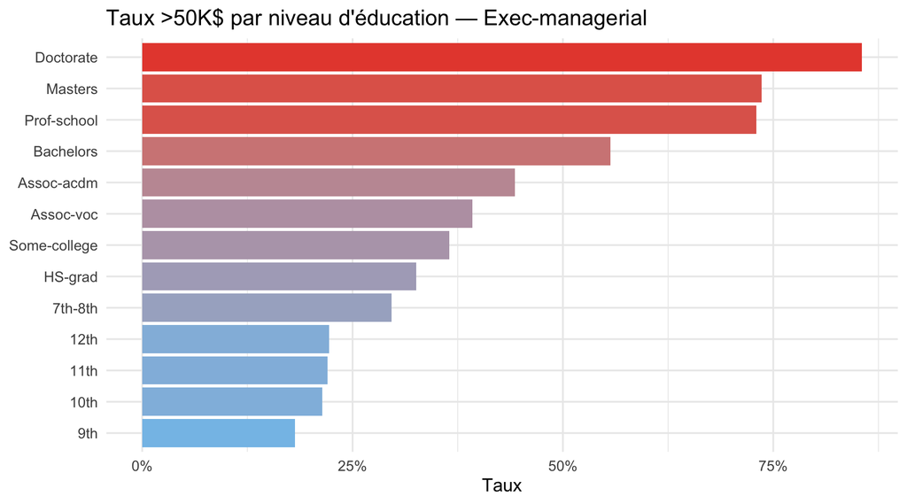

```r
adult_fe %>%
  group_by(education) %>%
  summarise(taux_risque = mean(income == ">50K"), n = n()) %>%
  filter(n > 10) %>%
  mutate(education = fct_reorder(education, taux_risque)) %>%
  ggplot(aes(x = education, y = taux_risque, fill = taux_risque)) +
  geom_col(show.legend = FALSE) +
  scale_y_continuous(labels = percent) +
  scale_fill_gradient(low = "#85C1E9", high = "#E74C3C") +
  coord_flip() +
  labs(title = sprintf("Taux >50K$ par niveau d'éducation — %s", label_occ),
       x = NULL, y = "Taux") +
  theme_minimal(base_size = 13)
```

## 2.6 Taux de risque par statut marital

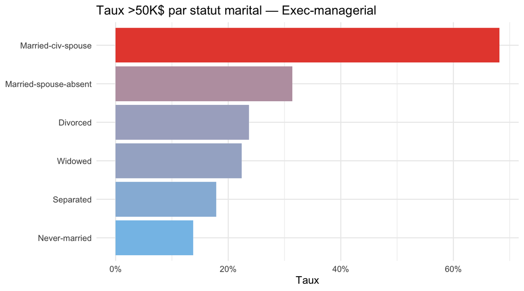

```r
adult_fe %>%
  group_by(marital_status) %>%
  summarise(taux_risque = mean(income == ">50K"), n = n()) %>%
  filter(n > 10) %>%
  mutate(marital_status = fct_reorder(marital_status, taux_risque)) %>%
  ggplot(aes(x = marital_status, y = taux_risque, fill = taux_risque)) +
  geom_col(show.legend = FALSE) +
  scale_y_continuous(labels = percent) +
  scale_fill_gradient(low = "#85C1E9", high = "#E74C3C") +
  coord_flip() +
  labs(title = sprintf("Taux >50K$ par statut marital — %s", label_occ),
       x = NULL, y = "Taux") +
  theme_minimal(base_size = 13)
```

## 2.7 Matrice de corrélation

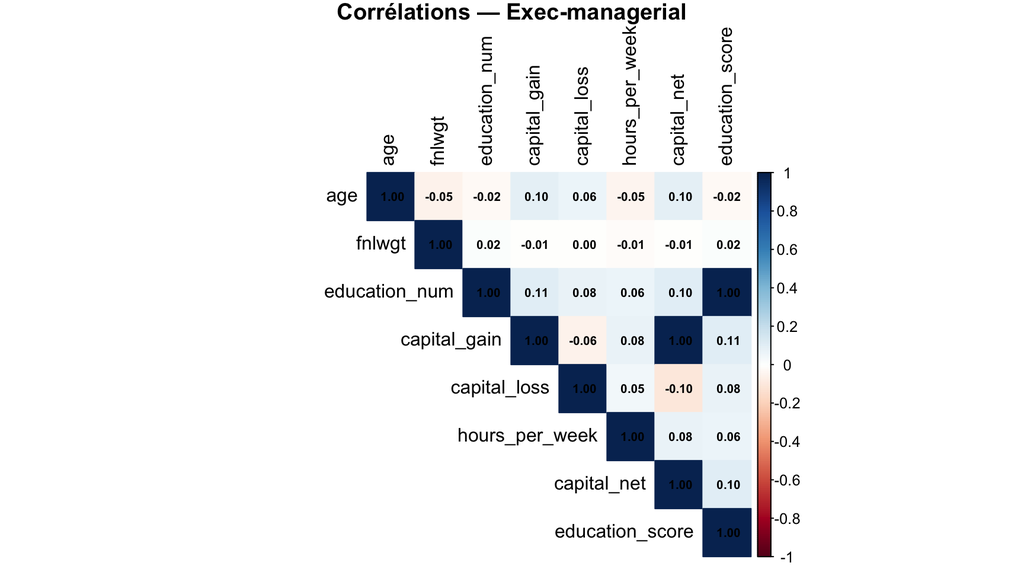

```r
vars_num <- adult_fe %>%
  select(age, fnlwgt, education_num, capital_gain, capital_loss,
         hours_per_week, capital_net, education_score) %>%
  cor()

corrplot(vars_num, method = "color", type = "upper",
         tl.col = "black", addCoef.col = "black",
         number.cex = 0.65,
         title = sprintf("Corrélations — %s", label_occ),
         mar = c(0, 0, 1, 0))
```

# 3 Feature Engineering

## 3.1 Variables créées

| Variable | Définition | Justification |
| --- | --- | --- |
| `age_group` | Tranche d’âge (4 catégories) | Relation non-linéaire âge–revenu |
| `capital_net` | `capital_gain - capital_loss` | Solde effectif d’activité financière |
| `high_hours` | `hours_per_week > 50` | Sur-travail comme signal de revenu élevé |
| `education_score` | Copie ordinale de `education_num` | Lisibilité dans le pipeline |
| `has_capital` | `capital_gain > 0` OU `capital_loss > 0` | Participation aux marchés financiers |

Pour la profession **Exec-managerial** : 20.5% ont un capital actif (has_capital = Oui), 18.6% travaillent plus de 50h (high_hours = Oui).

## 3.2 Distribution de capital_net

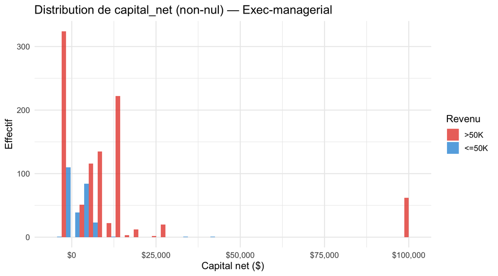

```r
adult_fe %>%
  filter(abs(capital_net) > 0) %>%
  ggplot(aes(x = capital_net, fill = income)) +
  geom_histogram(bins = 40, position = "dodge", alpha = 0.8) +
  scale_x_continuous(labels = dollar) +
  scale_fill_manual(values = c("#E74C3C", "#3498DB")) +
  labs(title = sprintf("Distribution de capital_net (non-nul) — %s", label_occ),
       x = "Capital net ($)", y = "Effectif", fill = "Revenu") +
  theme_minimal(base_size = 13)
```

# 4 Modélisation

Le modèle est entraîné et évalué exclusivement sur les individus **Exec-managerial** (n train = 3193).

## 4.1 Pipeline de pré-traitement

```r
rec <- recipe(income ~ ., data = train_d) %>%
  step_rm(fnlwgt, education) %>%
  step_dummy(all_nominal_predictors(), one_hot = TRUE) %>%
  step_zv(all_predictors()) %>%
  step_normalize(all_numeric_predictors()) %>%
  step_smote(income, over_ratio = 0.8)
```

## 4.2 Résultats du tuning

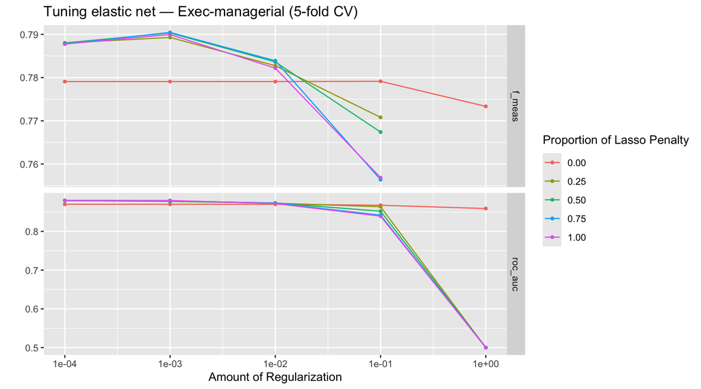

```r
autoplot(log_res) +
  labs(title = sprintf("Tuning elastic net — %s (5-fold CV)", label_occ))
```

```r
collect_metrics(log_res) %>%
  filter(.metric == "roc_auc") %>%
  arrange(desc(mean)) %>%
  head(10) %>%
  select(penalty, mixture, mean, std_err) %>%
  gt() %>%
  tab_header(title = sprintf("Top 10 AUC-ROC — %s", label_occ)) %>%
  fmt_number(columns = c(penalty, mixture, mean, std_err), decimals = 4)
```

Top 10 AUC-ROC — Exec-managerial

| penalty | mixture | mean | std_err |
| --- | --- | --- | --- |
| 0.0001 | 1.0000 | 0.8802 | 0.0068 |
| 0.0001 | 0.7500 | 0.8800 | 0.0068 |
| 0.0010 | 1.0000 | 0.8797 | 0.0067 |
| 0.0001 | 0.5000 | 0.8797 | 0.0068 |
| 0.0001 | 0.2500 | 0.8794 | 0.0069 |
| 0.0010 | 0.7500 | 0.8789 | 0.0068 |
| 0.0010 | 0.5000 | 0.8782 | 0.0069 |
| 0.0010 | 0.2500 | 0.8774 | 0.0070 |
| 0.0100 | 0.5000 | 0.8733 | 0.0070 |
| 0.0100 | 0.7500 | 0.8730 | 0.0069 |

# 5 Évaluation du meilleur modèle

Le meilleur modèle pour **Exec-managerial** atteint un AUC-ROC de **0.884** et un F1 de **0.793**.

```r
collect_metrics(final_fit) %>%
  gt() %>%
  tab_header(title = sprintf("Métriques finales — %s", label_occ))
```

Métriques finales — Exec-managerial

| .metric | .estimator | .estimate | .config |
| --- | --- | --- | --- |
| accuracy | binary | 0.7959950 | pre0_mod0_post0 |
| roc_auc | binary | 0.8838388 | pre0_mod0_post0 |
| brier_class | binary | 0.1386265 | pre0_mod0_post0 |

## 5.1 Matrice de confusion

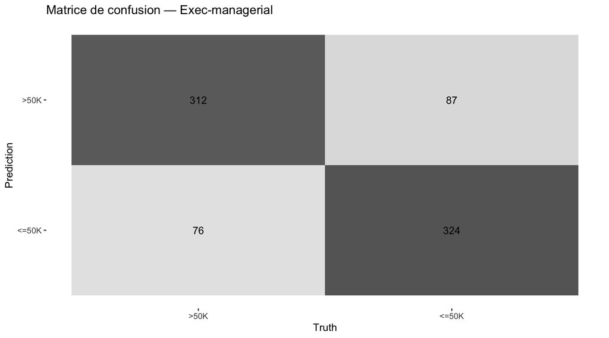

```r
conf_mat(preds, truth = income, estimate = .pred_class) %>%
  autoplot(type = "heatmap") +
  labs(title = sprintf("Matrice de confusion — %s", label_occ))
```

## 5.2 Courbe ROC

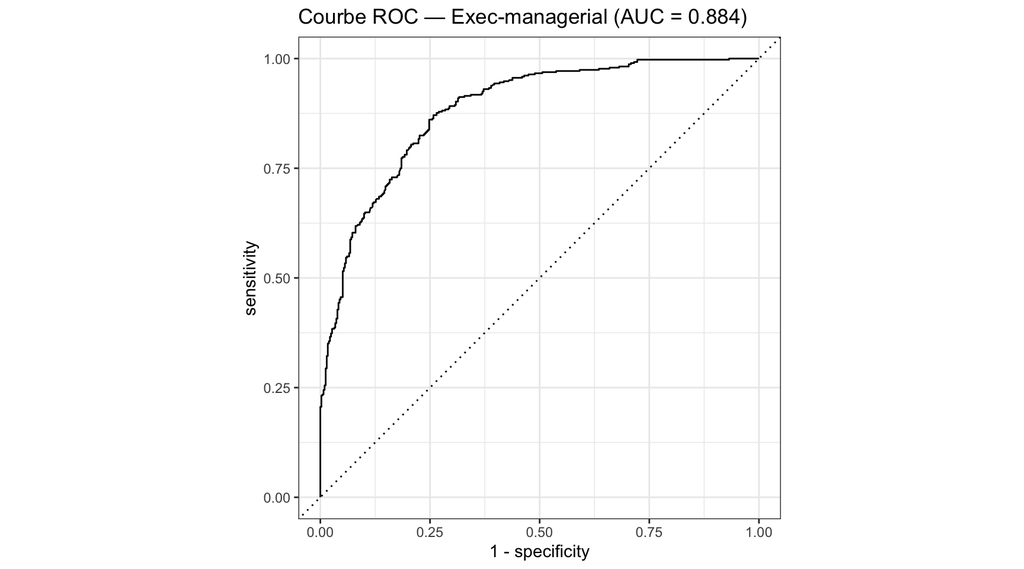

```r
preds %>%
  roc_curve(truth = income, `.pred_>50K`) %>%
  autoplot() +
  labs(title = sprintf("Courbe ROC — %s (AUC = %.3f)", label_occ, auc_final))
```